# Creating Publication-Quality Graphics in R

Leighton Pritchard

University of Strathclyde

2025-11-04

# 1. Summary and Setup

## Software and files

- We will need the gapminder dataset
  - https://swcarpentry.github.io/r-novice-gapminder/data/gapminder_data.csv

[figure not shown]

Figure 1: Link to download gapminder data

# 2. Packages

## Packages

**R packages**

- a collection (or *library*) of reusable code
- many useful and specialist tools are distributed as packages
- over 10,000 packages are available at `CRAN`
- you can distribute your own code as a package

**INTERACTIVE DEMO**

```r
installed.packages()               # see installed packages
install.packages("packagename")    # install a new package
update.packages()                  # update installed packages
library(packagename)               # import a package for use in your code
```

CRAN - the Comprehensive `R` Archive Network: https://cran.r-project.org/

## Challenge (2min)

**Check if the following packages are installed on your system, and install them if necessary.**

```r
dplyr
ggplot2
knitr
```

# 3. Creating publication-quality graphics in R

## Visualisation is Critical!

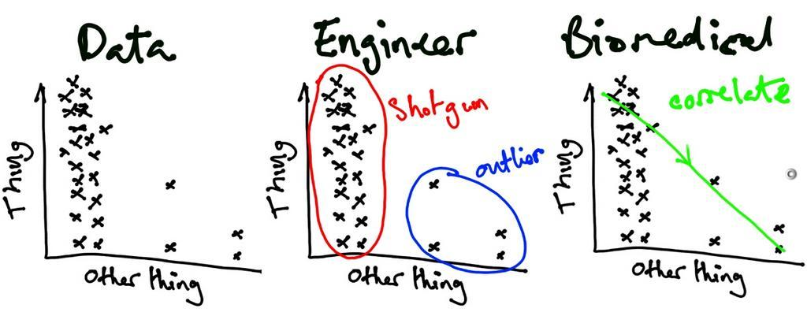

Figure 2: How scientists see the same data may vary by field

## The Grammar of Graphics

**What is `ggplot2`?**

- part of the *Tidyverse*, a collection of packages for data science
  - `ggplot2` is the graphics package
- **Implements the “Grammar of Graphics”**
  - Separates data from its representation
  - Helps iteratively update/refine plots
  - Helps build complex, effective visualisations from simple elements

**Four pillars of `ggplot2`**

- *data*
- *aesthetics*
- `geom`s
- *layers*
- Tidyverse: https://www.tidyverse.org/

## A Basic Scatterplot

**You can use `ggplot2` like `R`’s base graphics**

`qplot()` ≈ `plot()`

**INTERACTIVE DEMO**

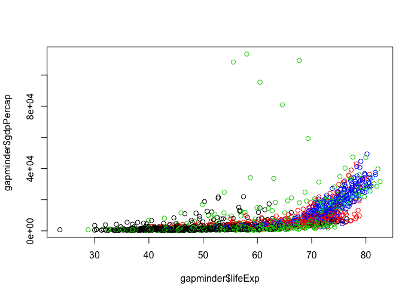

Figure 3: Scatterplot using base graphics

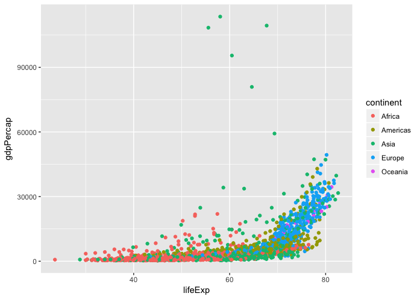

Figure 4: Scatterplot using `ggplot2`

```r
library(ggplot2)
plot(gapminder$lifeExp, gapminder$gdpPercap, col=gapminder$continent)
qplot(lifeExp, gdpPercap, data=gapminder, colour=continent)
```

## What is a Plot? 1

**Plot aesthetics**

- Each observation in the *data* is a point
- A point’s *aesthetics* determine how it is rendered
  - co-ordinates on the image; size; shape; colour
- *aesthetics* can be constant or mapped to variables
- **Many different plots can be generated from the same data by changing *aesthetics***

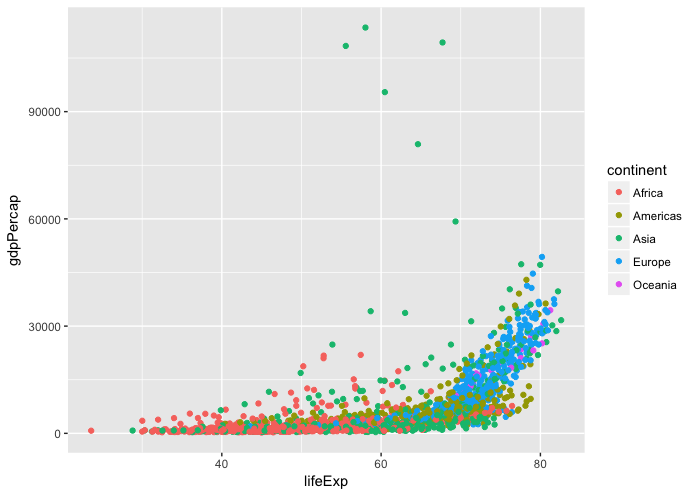

Figure 5: Scatterplot generated with `qplot()`